# Supervised Learning - Foundations Project: ReCell

## Problem Statement

### Business Context

Buying and selling used phones and tablets used to be something that happened on a handful of online marketplace sites. But the used and refurbished device market has grown considerably over the past decade, and a new IDC (International Data Corporation) forecast predicts that the used phone market would be worth \$52.7bn by 2023 with a compound annual growth rate (CAGR) of 13.6% from 2018 to 2023. This growth can be attributed to an uptick in demand for used phones and tablets that offer considerable savings compared with new models.

Refurbished and used devices continue to provide cost-effective alternatives to both consumers and businesses that are looking to save money when purchasing one. There are plenty of other benefits associated with the used device market. Used and refurbished devices can be sold with warranties and can also be insured with proof of purchase. Third-party vendors/platforms, such as Verizon, Amazon, etc., provide attractive offers to customers for refurbished devices. Maximizing the longevity of devices through second-hand trade also reduces their environmental impact and helps in recycling and reducing waste. The impact of the COVID-19 outbreak may further boost this segment as consumers cut back on discretionary spending and buy phones and tablets only for immediate needs.

### Objective

The rising potential of this comparatively under-the-radar market fuels the need for an ML-based solution to develop a dynamic pricing strategy for used and refurbished devices. ReCell, a startup aiming to tap the potential in this market, has hired you as a data scientist. They want you to analyze the data provided and build a linear regression model to predict the price of a used phone/tablet and identify factors that significantly influence it.

### Data Description

The data contains the different attributes of used/refurbished phones and tablets. The data was collected in the year 2021. The detailed data dictionary is given below.

- brand_name: Name of manufacturing brand
- os: OS on which the device runs
- screen_size: Size of the screen in cm
- 4g: Whether 4G is available or not
- 5g: Whether 5G is available or not
- main_camera_mp: Resolution of the rear camera in megapixels
- selfie_camera_mp: Resolution of the front camera in megapixels
- int_memory: Amount of internal memory (ROM) in GB
- ram: Amount of RAM in GB
- battery: Energy capacity of the device battery in mAh
- weight: Weight of the device in grams
- release_year: Year when the device model was released
- days_used: Number of days the used/refurbished device has been used
- normalized_new_price: Normalized price of a new device of the same model in euros
- normalized_used_price: Normalized price of the used/refurbished device in euros

## Importing necessary libraries

```python
# Installing the libraries with the specified version.
# uncomment and run the following line if Google Colab is being used
!pip install scikit-learn==1.2.2 seaborn==0.13.1 matplotlib==3.7.1 numpy==1.25.2 pandas==1.5.3 -q --user
```

**Note**: *After running the above cell, kindly restart the notebook kernel and run all cells sequentially from the start again.*

```python
# Importing all the necessary libraries
import numpy as np
import pandas as pd

# for data visualization
import matplotlib.pyplot as plt
import seaborn as sns

sns.set()

# split the data into train and test
from sklearn.model_selection import train_test_split

# to build linear regression_model
from sklearn.linear_model import LinearRegression

# to check model performance
from sklearn.metrics import mean_absolute_error, mean_squared_error, r2_score

# to build linear regression_model using statsmodels
import statsmodels.api as sm

# to compute VIF
from statsmodels.stats.outliers_influence import variance_inflation_factor
```

## Loading the dataset

```python
#Mount the Drive
from google.colab import drive
drive.mount('/content/drive')

# Read in the data set.
data = pd.read_csv('/content/drive/MyDrive/used_device_data.csv')
```

## Data Overview

- Observations
- Sanity checks

#### a) Displaying the first few rows of the dataset, and the last few rows.

```python
data.head()
```

|  | brand_name | os | screen_size | 4g | 5g | main_camera_mp | selfie_camera_mp | int_memory | ram | battery | weight | release_year | days_used | normalized_used_price | normalized_new_price |
| --- | --- | --- | --- | --- | --- | --- | --- | --- | --- | --- | --- | --- | --- | --- | --- |
| 0 | Honor | Android | 14.50 | yes | no | 13.0 | 5.0 | 64.0 | 3.0 | 3020.0 | 146.0 | 2020 | 127 | 4.307572 | 4.715100 |
| 1 | Honor | Android | 17.30 | yes | yes | 13.0 | 16.0 | 128.0 | 8.0 | 4300.0 | 213.0 | 2020 | 325 | 5.162097 | 5.519018 |
| 2 | Honor | Android | 16.69 | yes | yes | 13.0 | 8.0 | 128.0 | 8.0 | 4200.0 | 213.0 | 2020 | 162 | 5.111084 | 5.884631 |
| 3 | Honor | Android | 25.50 | yes | yes | 13.0 | 8.0 | 64.0 | 6.0 | 7250.0 | 480.0 | 2020 | 345 | 5.135387 | 5.630961 |
| 4 | Honor | Android | 15.32 | yes | no | 13.0 | 8.0 | 64.0 | 3.0 | 5000.0 | 185.0 | 2020 | 293 | 4.389995 | 4.947837 |

```python
data.tail()
```

|  | brand_name | os | screen_size | 4g | 5g | main_camera_mp | selfie_camera_mp | int_memory | ram | battery | weight | release_year | days_used | normalized_used_price | normalized_new_price |
| --- | --- | --- | --- | --- | --- | --- | --- | --- | --- | --- | --- | --- | --- | --- | --- |
| 3449 | Asus | Android | 15.34 | yes | no | NaN | 8.0 | 64.0 | 6.0 | 5000.0 | 190.0 | 2019 | 232 | 4.492337 | 6.483872 |
| 3450 | Asus | Android | 15.24 | yes | no | 13.0 | 8.0 | 128.0 | 8.0 | 4000.0 | 200.0 | 2018 | 541 | 5.037732 | 6.251538 |
| 3451 | Alcatel | Android | 15.80 | yes | no | 13.0 | 5.0 | 32.0 | 3.0 | 4000.0 | 165.0 | 2020 | 201 | 4.357350 | 4.528829 |
| 3452 | Alcatel | Android | 15.80 | yes | no | 13.0 | 5.0 | 32.0 | 2.0 | 4000.0 | 160.0 | 2020 | 149 | 4.349762 | 4.624188 |
| 3453 | Alcatel | Android | 12.83 | yes | no | 13.0 | 5.0 | 16.0 | 2.0 | 4000.0 | 168.0 | 2020 | 176 | 4.132122 | 4.279994 |

#### b) Checking the shape of the data set.

```python
data.shape
```

```
(3454, 15)
```

#### c) Checking the data types of the columns for the dataset.

```python
data.info()
```

```
<class 'pandas.core.frame.DataFrame'>
RangeIndex: 3454 entries, 0 to 3453
Data columns (total 15 columns):
 #   Column                 Non-Null Count  Dtype
---  ------                 --------------  -----
 0   brand_name             3454 non-null   object
 1   os                     3454 non-null   object
 2   screen_size            3454 non-null   float64
 3   4g                     3454 non-null   object
 4   5g                     3454 non-null   object
 5   main_camera_mp         3275 non-null   float64
 6   selfie_camera_mp       3452 non-null   float64
 7   int_memory             3450 non-null   float64
 8   ram                    3450 non-null   float64
 9   battery                3448 non-null   float64
 10  weight                 3447 non-null   float64
 11  release_year           3454 non-null   int64
 12  days_used              3454 non-null   int64
 13  normalized_used_price  3454 non-null   float64
 14  normalized_new_price   3454 non-null   float64
dtypes: float64(9), int64(2), object(4)
memory usage: 404.9+ KB
```

#### d) Checking the statistical summary of the data.

```python
data.describe()
```

|  | screen_size | main_camera_mp | selfie_camera_mp | int_memory | ram | battery | weight | release_year | days_used | normalized_used_price | normalized_new_price |
| --- | --- | --- | --- | --- | --- | --- | --- | --- | --- | --- | --- |
| count | 3454.000000 | 3275.000000 | 3452.000000 | 3450.000000 | 3450.000000 | 3448.000000 | 3447.000000 | 3454.000000 | 3454.000000 | 3454.000000 | 3454.000000 |
| mean | 13.713115 | 9.460208 | 6.554229 | 54.573099 | 4.036122 | 3133.402697 | 182.751871 | 2015.965258 | 674.869716 | 4.364712 | 5.233107 |
| std | 3.805280 | 4.815461 | 6.970372 | 84.972371 | 1.365105 | 1299.682844 | 88.413228 | 2.298455 | 248.580166 | 0.588914 | 0.683637 |
| min | 5.080000 | 0.080000 | 0.000000 | 0.010000 | 0.020000 | 500.000000 | 69.000000 | 2013.000000 | 91.000000 | 1.536867 | 2.901422 |
| 25% | 12.700000 | 5.000000 | 2.000000 | 16.000000 | 4.000000 | 2100.000000 | 142.000000 | 2014.000000 | 533.500000 | 4.033931 | 4.790342 |
| 50% | 12.830000 | 8.000000 | 5.000000 | 32.000000 | 4.000000 | 3000.000000 | 160.000000 | 2015.500000 | 690.500000 | 4.405133 | 5.245892 |
| 75% | 15.340000 | 13.000000 | 8.000000 | 64.000000 | 4.000000 | 4000.000000 | 185.000000 | 2018.000000 | 868.750000 | 4.755700 | 5.673718 |
| max | 30.710000 | 48.000000 | 32.000000 | 1024.000000 | 12.000000 | 9720.000000 | 855.000000 | 2020.000000 | 1094.000000 | 6.619433 | 7.847841 |

#### e) Checking for duplicate values

```python
duplicate_rows = data[data.duplicated()]
print("Duplicate Rows:")
#If we had duplicates we'd use the following line to drop them.
# df.drop_duplicates(inplace=True)
```

```
Duplicate Rows:
```

#### f) Checking for missing values.

```python
missing_values = data.isna().sum()
print("Missing Values:")
print(missing_values)
```

```
Missing Values:
brand_name                 0
os                         0
screen_size                0
4g                         0
5g                         0
main_camera_mp           179
selfie_camera_mp           2
int_memory                 4
ram                        4
battery                    6
weight                     7
release_year               0
days_used                  0
normalized_used_price      0
normalized_new_price       0
dtype: int64
```

#### g) Make a copy of the data to work with.

```python
df= data.copy
```

## Exploratory Data Analysis (EDA)

- EDA is an important part of any project involving data.
- It is important to investigate and understand the data better before building a model with it.
- A few questions have been mentioned below which will help you approach the analysis in the right manner and generate insights from the data.
- A thorough analysis of the data, in addition to the questions mentioned below, should be done.

**Questions**:

1. What does the distribution of normalized used device prices look like?
2. What percentage of the used device market is dominated by Android devices?
3. The amount of RAM is important for the smooth functioning of a device. How does the amount of RAM vary with the brand?
4. A large battery often increases a device's weight, making it feel uncomfortable in the hands. How does the weight vary for phones and tablets offering large batteries (more than 4500 mAh)?
5. Bigger screens are desirable for entertainment purposes as they offer a better viewing experience. How many phones and tablets are available across different brands with a screen size larger than 6 inches?
6. A lot of devices nowadays offer great selfie cameras, allowing us to capture our favorite moments with loved ones. What is the distribution of devices offering greater than 8MP selfie cameras across brands?
7. Which attributes are highly correlated with the normalized price of a used device?

### Univariate Analysis

##### 1. Brand Name

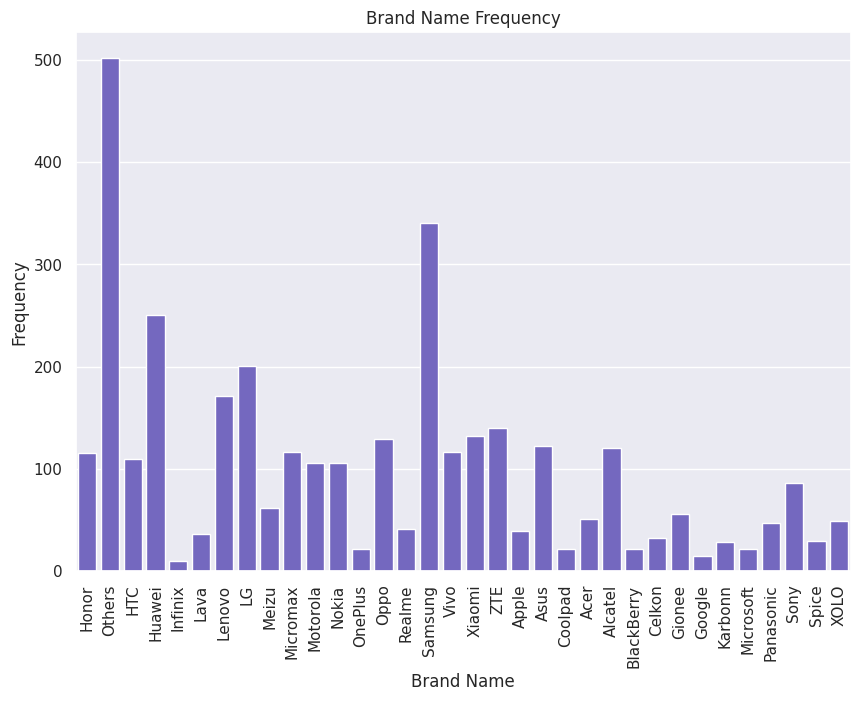

```
Stats for the Brand Name column
--------------------------------------------------
```

```
count       3454
unique        34
top       Others
freq         502
Name: brand_name, dtype: object
```

```python
plt.figure(figsize=(10,7))
plt.title("Brand Name Frequency")
plt.xlabel('Brand Name')
plt.ylabel('Frequency')

sns.countplot(data=data, x='brand_name', color='slateblue')
plt.xticks(rotation=90)
plt.show()
print('\n')
print('Stats for the Brand Name column')
print('-'*50)
data['brand_name'].describe()
```

Observation:

[output not shown]

##### 2. OS

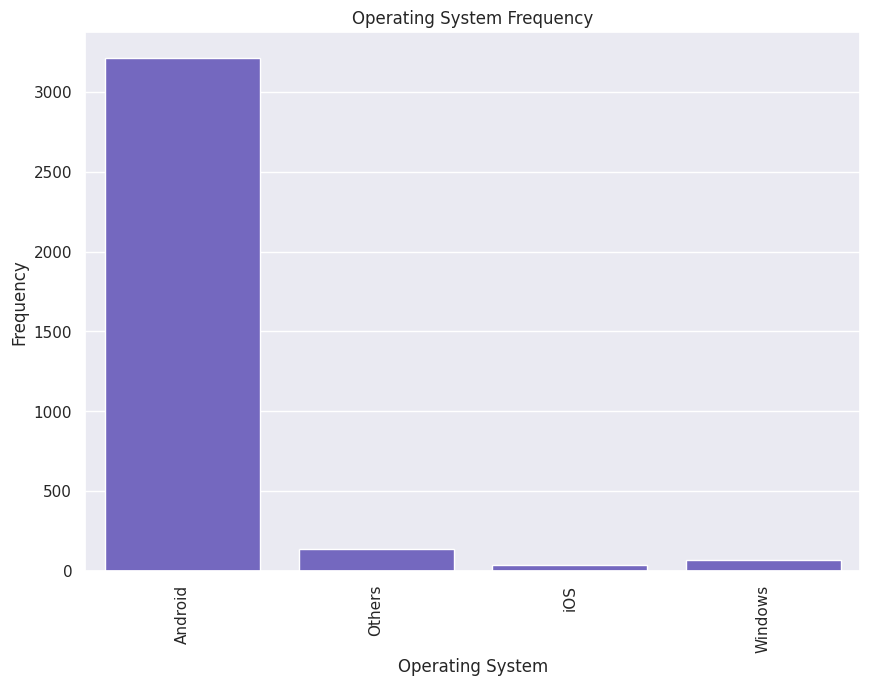

```
Stats for the  Operating System column
--------------------------------------------------
```

```
count        3454
unique          4
top       Android
freq         3214
Name: os, dtype: object
```

```python
plt.figure(figsize=(10,7))
plt.title("Operating System Frequency")
plt.xlabel('Operating System')
plt.ylabel('Frequency')

sns.countplot(data=data, x='os', color='slateblue')
plt.xticks(rotation=90)
plt.show()
print('\n')
print('Stats for the  Operating System column')
print('-'*50)
data['os'].describe()
```

Observations:

```
* Android is clearly betting iOS. Although given that there are so many phones brands and records is doesn't seem likely Android OS is the reason why someone would specifically go for an older used phone.
```

##### 3. 4G

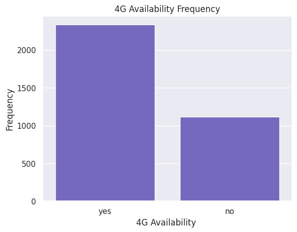

```
Stats for the 4g column
--------------------------------------------------
```

```
count     3454
unique       2
top        yes
freq      2335
Name: 4g, dtype: object
```

```python
plt.title("4G Availability Frequency")
plt.xlabel('4G Availability ')
plt.ylabel('Frequency')
sns.countplot(data=data, x='4g', color='slateblue')
plt.show()


print('\n')
print('Stats for the 4g column')
print('-'*50)
data['4g'].describe()
```

Observations

```
* Naturally used phones will have older network generational capabilities.
* So we see that some of the older phones have 4G networks available but not 5G capability. These might even have 3G.
```

##### 4. 5G

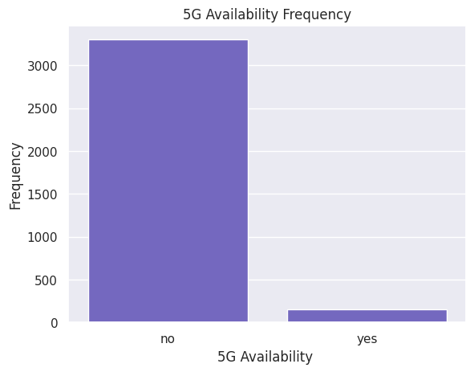

```
Stats for the 5g column
--------------------------------------------------
```

```
count     3454
unique       2
top         no
freq      3302
Name: 5g, dtype: object
```

```python
plt.title("5G Availability Frequency")
plt.xlabel('5G Availability ')
plt.ylabel('Frequency')
sns.countplot(data=data, x='5g', color='slateblue')
plt.show()


print('\n')
print('Stats for the 5g column')
print('-'*50)
data['5g'].describe()
```

Observations:

```
*Again some older phones may not have the newer generations capabilities for network access.
*Here we see that very few actually have 5G access.
```

##### 5. Release Year

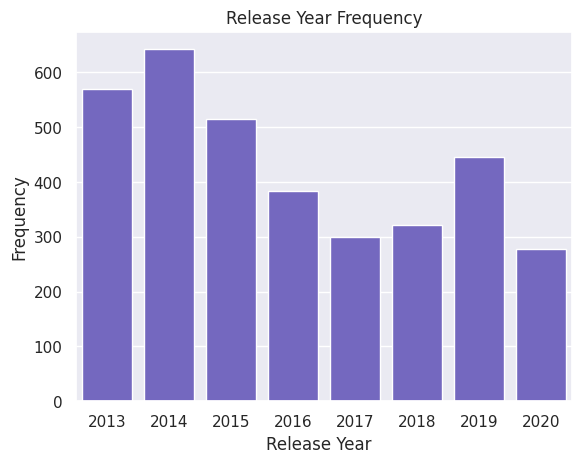

```
Stats for the Release Year  column
--------------------------------------------------
```

```
count    3454.000000
mean     2015.965258
std         2.298455
min      2013.000000
25%      2014.000000
50%      2015.500000
75%      2018.000000
max      2020.000000
Name: release_year, dtype: float64
```

```python
plt.title("Release Year Frequency")
plt.xlabel('Release Year  ')
plt.ylabel('Frequency')
sns.countplot(data=data, x='release_year', color='slateblue')
plt.show()


print('\n')
print('Stats for the Release Year  column')
print('-'*50)
data['release_year'].describe()
```

Observations:

```
* Clearly people dont' mind buying phones/tablets that are almost 8 years old given that our data was collcted in 2021.
* We know that COVID impactedc people purchasing powers, so we see a clear dip in purchases in 2020.
* Tablets are swapped out less frequently than phones so we could theorize that some tablets are being bought from older years.
* However it doesn't seem like the stock was lacking to buy phones from 4 + years ago. Like the case context said, refurbisehd and used devices c an still be sold with warranties andinsured and it also can reduce enrionemental impact so there are definitely reasons to hold on to them and sell them if you can.
```

##### 6. Ram

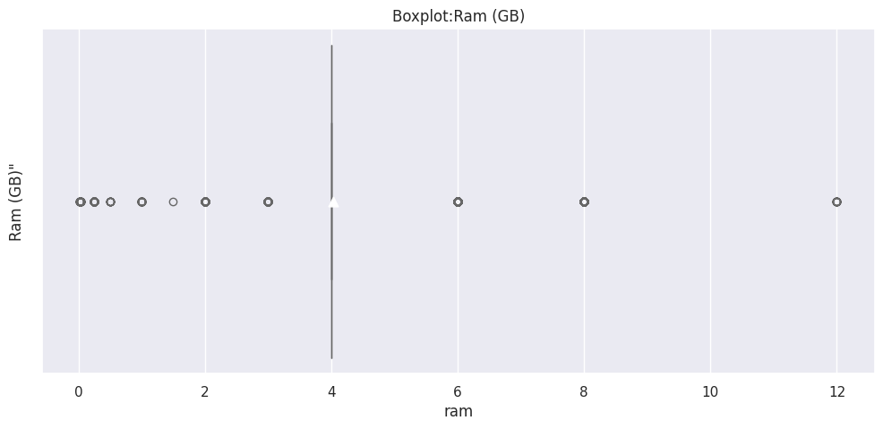

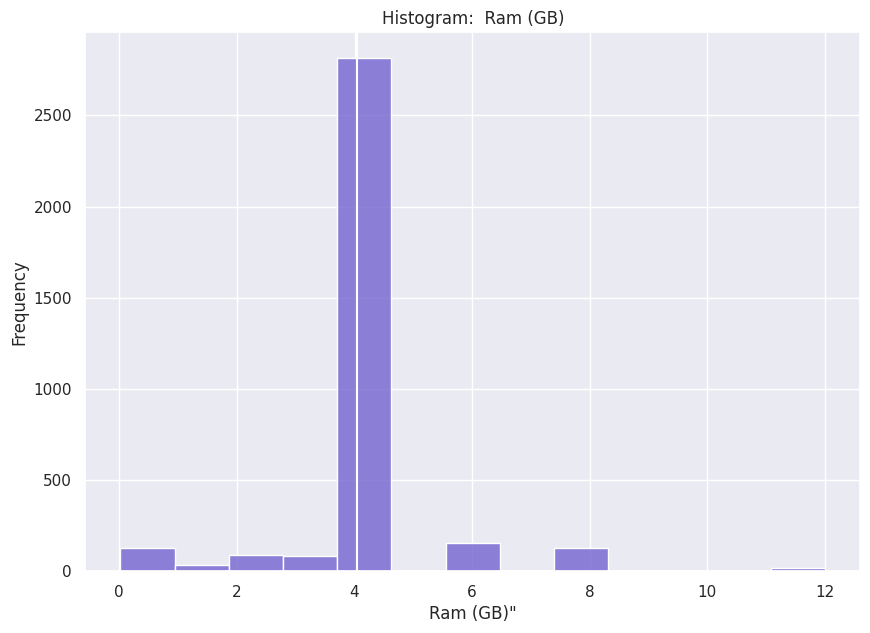

```python
mean_value = np.mean(data['ram'])
median_value = np.median(data['ram'])


plt.figure(figsize=(12,5))
plt.title('Boxplot:Ram (GB)')
plt.ylabel('Ram (GB)"')
sns.boxplot(data = data, x='ram', color='mediumslateblue')
plt.scatter(mean_value, 0, color='white', marker='^', s=60, zorder=10)
plt.show()


plt.figure(figsize=(10,7))
plt.title("Histogram:  Ram (GB)")
plt.xlabel('Ram (GB)"')
plt.ylabel('Frequency')
sns.histplot(data=data, x='ram', color='slateblue', kde=False)
plt.axvline(x=mean_value, color='white', linestyle='-', label='Mean')
plt.axvline(x=median_value, color='black', linestyle='-.', label='Median')
plt.show()
```

Observations

```
* Our painfully sole obeservation here is that most phones come with 4GB of ram.
* Even newer phones like the 2023 iPhone 15 have 6GB of ram, so I doubt this would be a highly influencing factor in anyones purchase of a phone.
```

##### 7. Int_Memory

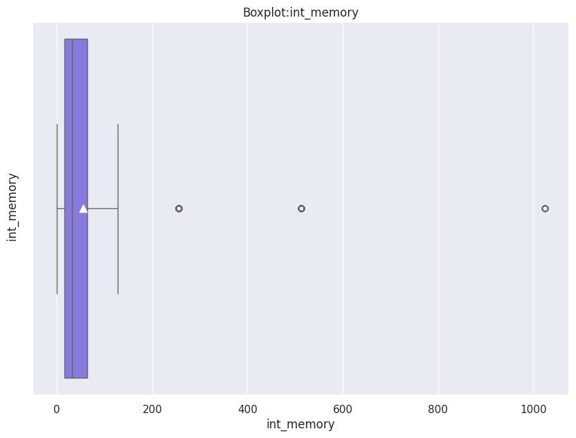

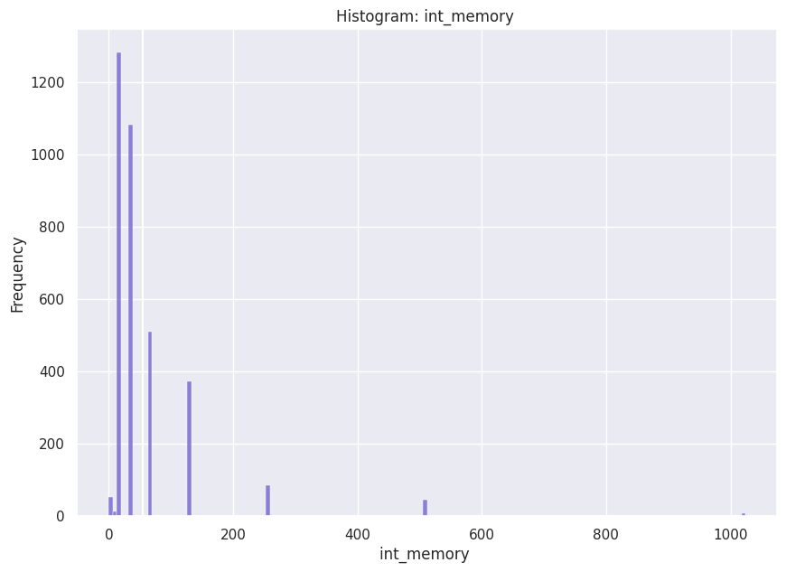

```python
mean_value = np.mean(data['int_memory'])
median_value = np.median(data['int_memory'])


plt.figure(figsize=(10,7))
plt.title('Boxplot:int_memory')
plt.ylabel(' int_memory')
sns.boxplot(data = data, x='int_memory', color='mediumslateblue')
plt.scatter(mean_value, 0, color='white', marker='^', s=60, zorder=10)
plt.show()


plt.figure(figsize=(10,7))
plt.title("Histogram: int_memory ")
plt.xlabel('int_memory ')
plt.ylabel('Frequency')
sns.histplot(data=data, x='int_memory', color='slateblue', kde=False)
plt.axvline(x=mean_value, color='white', linestyle='-', label='Mean')
plt.axvline(x=median_value, color='black', linestyle='-.', label='Median')
plt.show()
```

Observations:

[output not shown]

##### 8. Selfie Camera mp

[figure not shown]

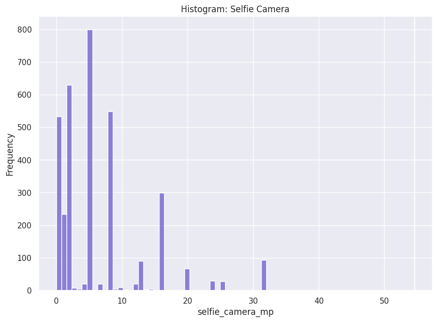

```python
plt.figure(figsize=(10,7))
plt.title('Selfie Camera')
sns.boxplot(data = data, x='selfie_camera_mp', color='mediumslateblue')
plt.scatter(mean_value, 0, color='white', marker='^', s=60, zorder=10)
plt.show()


plt.figure(figsize=(10,7))
plt.title("Histogram: Selfie Camera")
plt.xlabel('selfie_camera_mp')
plt.ylabel('Frequency')
sns.histplot(data=data, x='selfie_camera_mp', color='slateblue', kde=False)
plt.axvline(x=mean_value, color='white', linestyle='-', label='Mean')
plt.axvline(x=median_value, color='black', linestyle='-.', label='Median')
plt.show()
```

Observations

```
* although we see most phones with under 10 mp for the selfie camera, we still high a high amount of people willing to purchase from 16-32 mp.
* Clearly this is something that does cause an impact when customers are searching for phones.
```

##### 9. Main Camera mp

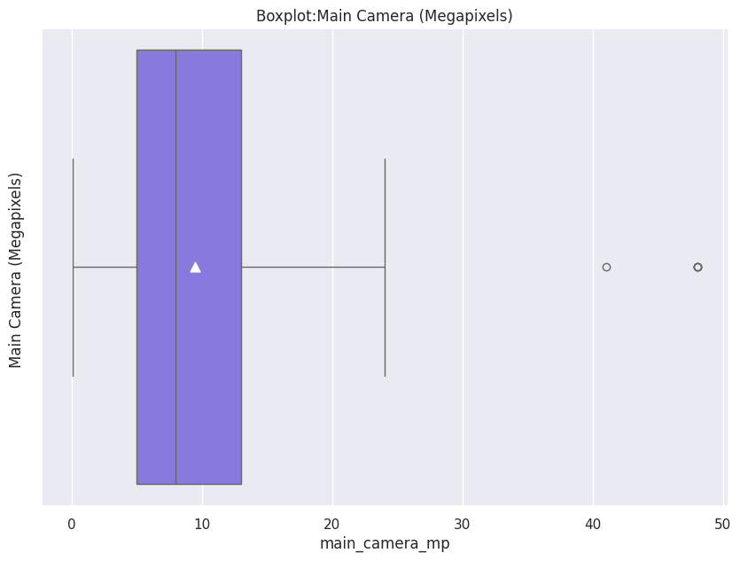

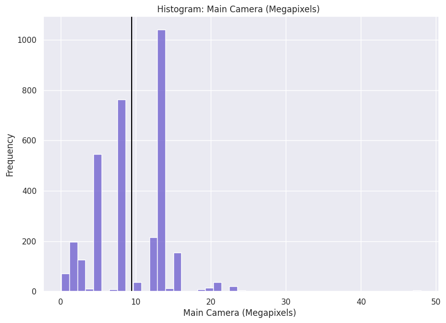

```python
mean_value = np.mean(data['main_camera_mp'])
median_value = np.median(data['main_camera_mp'])


plt.figure(figsize=(10,7))
plt.title('Boxplot:Main Camera (Megapixels)' )
plt.ylabel('Main Camera (Megapixels) ')
sns.boxplot(data = data, x='main_camera_mp', color='mediumslateblue')
plt.scatter(mean_value, 0, color='white', marker='^', s=60, zorder=10)
plt.show()


plt.figure(figsize=(10,7))
plt.title("Histogram: Main Camera (Megapixels)  ")
plt.xlabel('Main Camera (Megapixels) ')
plt.ylabel('Frequency')
sns.histplot(data=data, x='main_camera_mp', color='slateblue', kde=False)
plt.axvline(x=mean_value, color='black', linestyle='-', label='Mean')
plt.axvline(x=median_value, color='black', linestyle='-', label='Median')
plt.show()
```

Observations:

```
*It seems like 14 mp is what most people are looking for when getting their phoens.
*Clearly the camera quality does matter a lot to people.
```

##### 10. Screen_Size

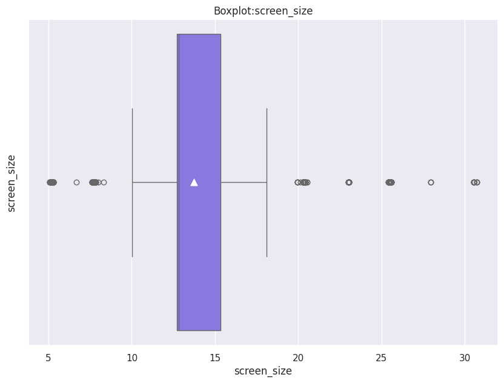

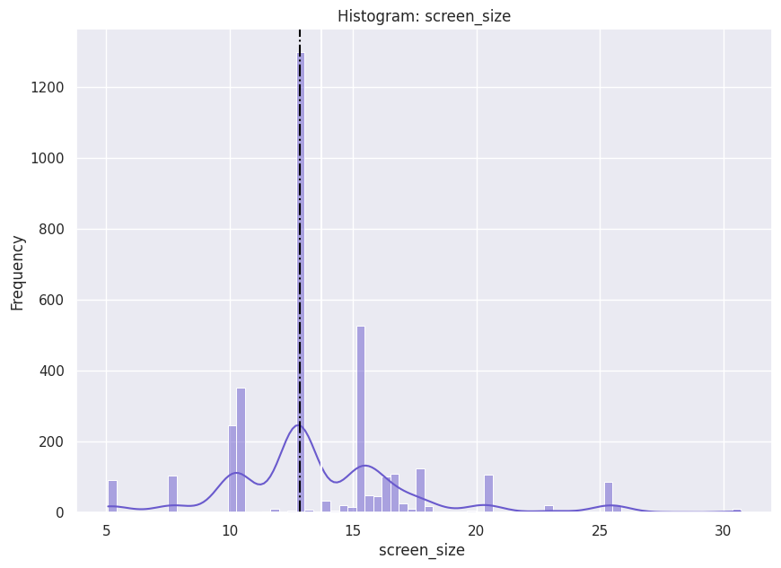

```python
mean_value = np.mean(data['screen_size'])
median_value = np.median(data['screen_size'])


plt.figure(figsize=(10,7))
plt.title('Boxplot:screen_size')
plt.ylabel('screen_size')
sns.boxplot(data = data, x='screen_size', color='mediumslateblue')
plt.scatter(mean_value, 0, color='white', marker='^', s=60, zorder=10)
plt.show()


plt.figure(figsize=(10,7))
plt.title("Histogram: screen_size")
plt.xlabel('screen_size ')
plt.ylabel('Frequency')
sns.histplot(data=data, x='screen_size', color='slateblue', kde=True)
plt.axvline(x=mean_value, color='white', linestyle='-', label='Mean')
plt.axvline(x=median_value, color='black', linestyle='-.', label='Median')
plt.show()
```

Observations:

[output not shown]

##### 11. Battery

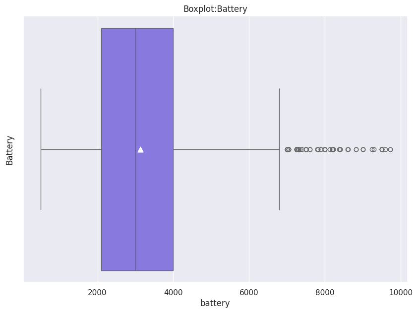

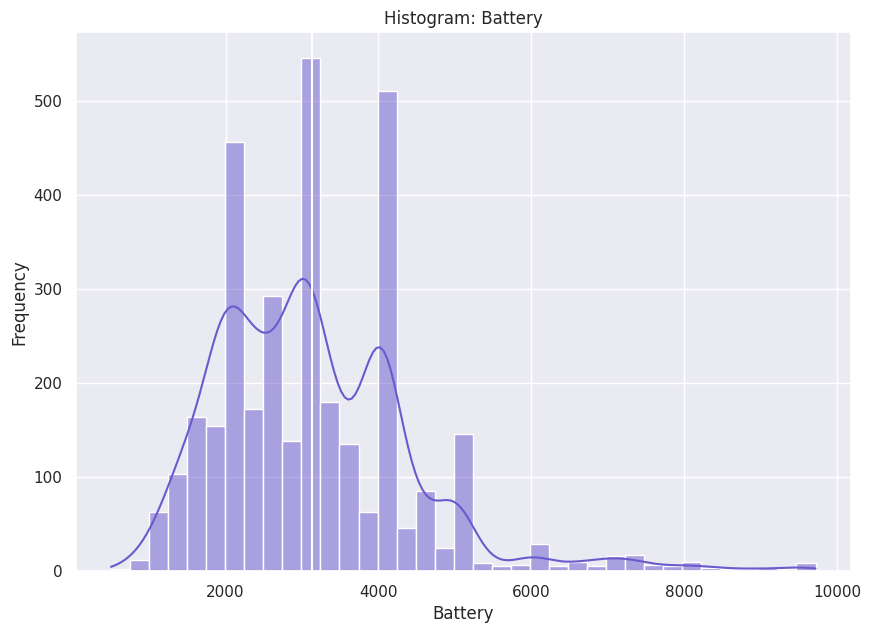

```python
mean_value = np.mean(data['battery'])
median_value = np.median(data['battery'])


plt.figure(figsize=(10,7))
plt.title('Boxplot:Battery')
plt.ylabel('Battery')
sns.boxplot(data = data, x='battery', color='mediumslateblue')
plt.scatter(mean_value, 0, color='white', marker='^', s=60, zorder=10)
plt.show()


plt.figure(figsize=(10,7))
plt.title("Histogram: Battery")
plt.xlabel('Battery')
plt.ylabel('Frequency')
sns.histplot(data=data, x='battery', color='slateblue', kde=True)
plt.axvline(x=mean_value, color='white', linestyle='-', label='Mean')
plt.axvline(x=median_value, color='black', linestyle='-.', label='Median')
plt.show()
```

Observations:

[output not shown]

##### 12. Weight

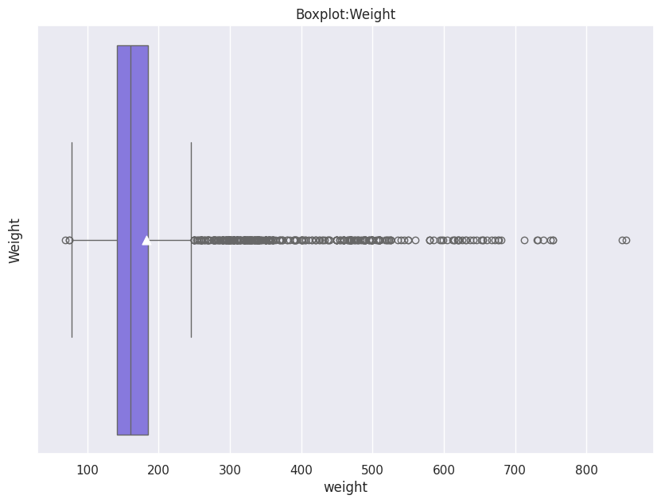

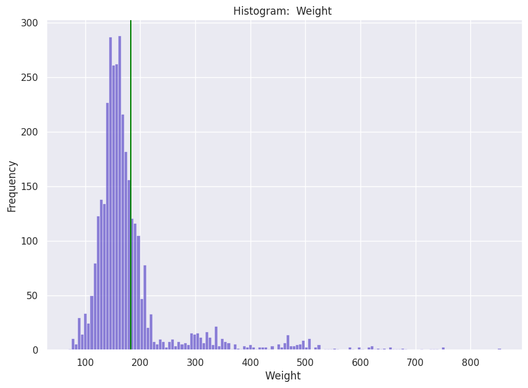

```python
mean_value = np.mean(data['weight'])
median_value = np.median(data['weight'])


plt.figure(figsize=(10,7))
plt.title('Boxplot:Weight')
plt.ylabel('Weight')
sns.boxplot(data = data, x='weight', color='mediumslateblue')
plt.scatter(mean_value, 0, color='white', marker='^', s=60, zorder=10)
plt.show()


plt.figure(figsize=(10,7))
plt.title("Histogram:  Weight ")
plt.xlabel('Weight ')
plt.ylabel('Frequency')
sns.histplot(data=data, x='weight', color='slateblue', kde=False)
plt.axvline(x=mean_value, color='green', linestyle='-', label='Mean')
plt.axvline(x=median_value, color='green', linestyle='-', label='Median')
plt.show()
```

Observations:

```
* The weight of the phone does seem to matter.
* We see that the majority of people get a phone under 250 grams.
* If they don't like the heavy feel of it when shopping for it, the customer might not want to carry it on their being for the next two years.
```

##### 13. Days_Used

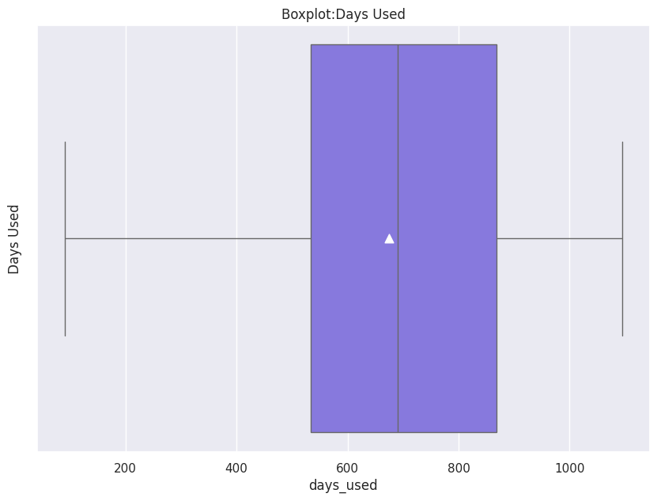

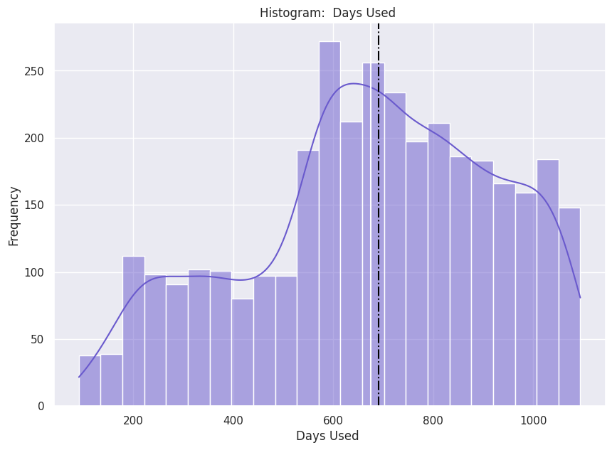

```python
mean_value = np.mean(data['days_used'])
median_value = np.median(data['days_used'])


plt.figure(figsize=(10,7))
plt.title('Boxplot:Days Used')
plt.ylabel('Days Used')
sns.boxplot(data = data, x='days_used', color='mediumslateblue')
plt.scatter(mean_value, 0, color='white', marker='^', s=60, zorder=10)
plt.show()


plt.figure(figsize=(10,7))
plt.title("Histogram:  Days Used ")
plt.xlabel('Days Used ')
plt.ylabel('Frequency')
sns.histplot(data=data, x='days_used', color='slateblue', kde=True)
plt.axvline(x=mean_value, color='white', linestyle='-', label='Mean')
plt.axvline(x=median_value, color='black', linestyle='-.', label='Median')
plt.show()
```

Observations:

```
* Here we see that most people will use their phone for a little under 2 years.
* Since we are handling used and refurbished phones here, we can assume that they may not be able to last as long as a new phone would.
* However since the case study said that there are still insurances and warranties offered on these phones, its doesn't seem like people are planning on buying temporary phones, or at the minimum they'll come back and get something newer if it doesn't last as expected.
```

##### 14. Normalized Used Price

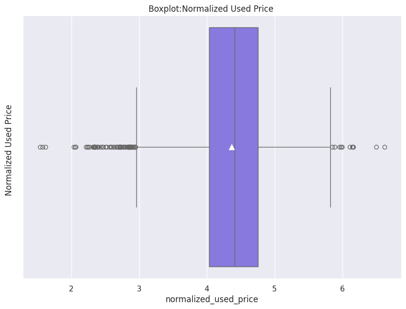

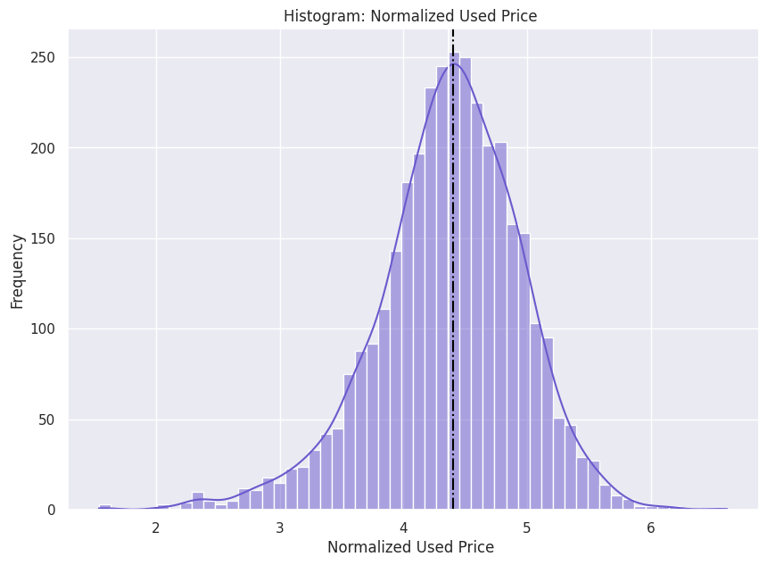

```python
mean_value = np.mean(data['normalized_used_price'])
median_value = np.median(data['normalized_used_price'])


plt.figure(figsize=(10,7))
plt.title('Boxplot:Normalized Used Price ')
plt.ylabel('Normalized Used Price  ')
sns.boxplot(data = data, x='normalized_used_price', color='mediumslateblue')
plt.scatter(mean_value, 0, color='white', marker='^', s=60, zorder=10)
plt.show()


plt.figure(figsize=(10,7))
plt.title("Histogram: Normalized Used Price ")
plt.xlabel('Normalized Used Price ')
plt.ylabel('Frequency')
sns.histplot(data=data, x='normalized_used_price', color='slateblue', kde=True)
plt.axvline(x=mean_value, color='white', linestyle='-', label='Mean')
plt.axvline(x=median_value, color='black', linestyle='-.', label='Median')
plt.show()
```

Observations

```
* We have a normal distribution
* in the box plot we see that we have some paid for at lower prices, we can presume on sale.
```

##### 15. Normalized New Price

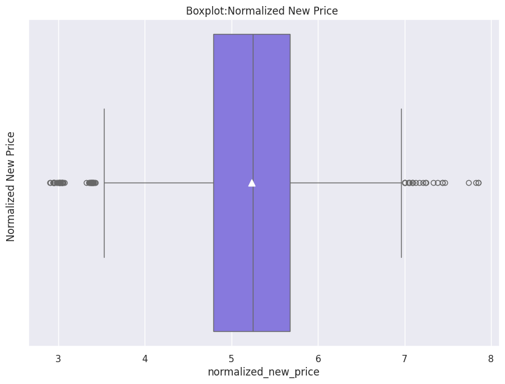

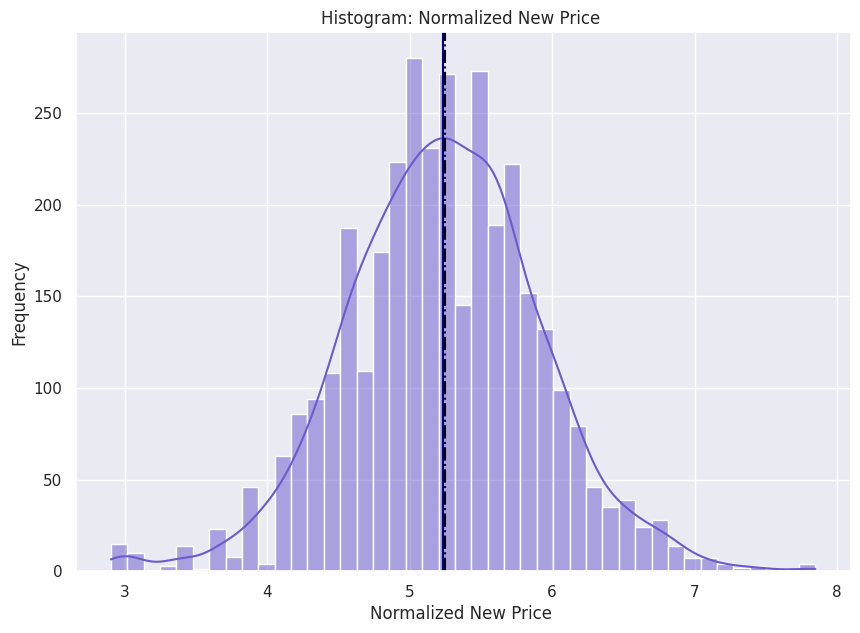

```python
mean_value = np.mean(data['normalized_new_price'])
median_value = np.median(data['normalized_new_price'])


plt.figure(figsize=(10,7))
plt.title('Boxplot:Normalized New Price ')
plt.ylabel('Normalized New Price  ')
sns.boxplot(data = data, x='normalized_new_price', color='mediumslateblue')
plt.scatter(mean_value, 0, color='white', marker='^', s=60, zorder=10)
plt.show()


plt.figure(figsize=(10,7))
plt.title("Histogram: Normalized New Price ")
plt.xlabel('Normalized New Price ')
plt.ylabel('Frequency')
sns.histplot(data=data, x='normalized_new_price', color='slateblue', kde=True)
plt.axvline(x=mean_value, color='navy', linestyle='-', label='Mean')
plt.axvline(x=median_value, color='black', linestyle='-.', label='Median')
plt.show()
```

Observations

```
* Here we see people are purchasing more since they are new, but we also see that soem people do pay a little higher for them as well.
```

### Bivariate Analysis

#### **Correlation Checking**

```python
# creating a copy of the data so that original data remains unchanged
df = data.copy()
```

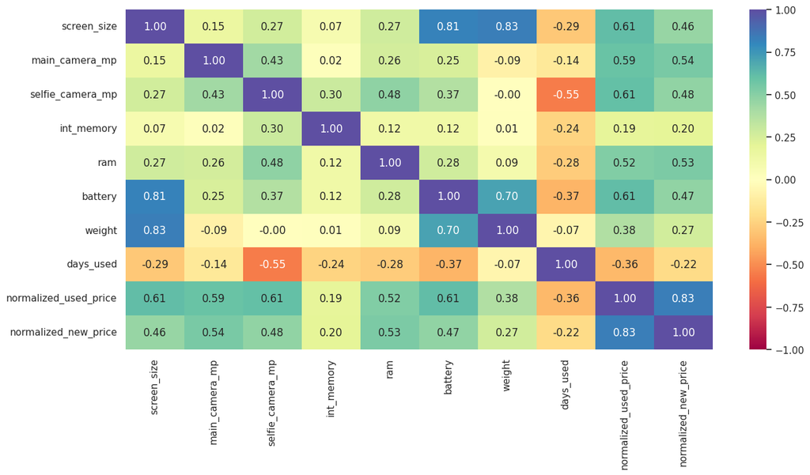

```python
cols_list = data.select_dtypes(include=np.number).columns.tolist()
# dropping release_year as it is a temporal variable
cols_list.remove("release_year")

plt.figure(figsize=(15, 7))
sns.heatmap(
    df[cols_list].corr(), annot=True, vmin=-1, vmax=1, fmt=".2f", cmap="Spectral"
)
plt.show()
```

Observations:

```
* Based on the correlation graph we can see that 6 main things influence the price of a used phone/tablet.
  1. The Price of a new phone
  2. The Main Camera mp capacity
  3. The Selfie Camera mp capacity
  4. The RAM
  5. The screen size
  6. The battery capacity.
```

#### **Ram Versus Brand Variations**

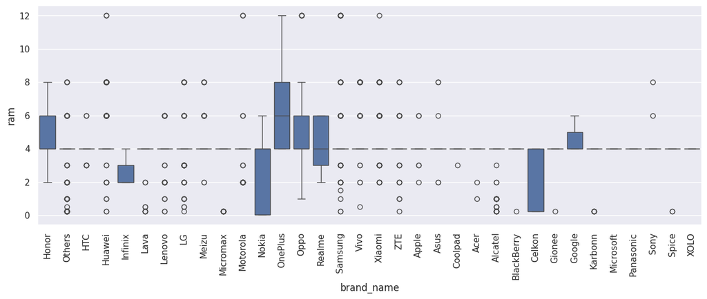

```python
plt.figure(figsize=(15, 5))
sns.boxplot(data=df, x="brand_name", y="ram")
plt.xticks(rotation=90)
plt.show()
```

Observations:

[output not shown]

#### **Battery Versus Weight Analysis**

```python
# People who travel frequently require devices with large batteries to run through the day. But large battery often increases weight,
# making it feel uncomfortable in the hands. Let's create a new dataframe of only those devices which offer a large battery and analyze.
df_large_battery = df[df.battery > 4500]
df_large_battery.shape
```

```
(341, 15)
```

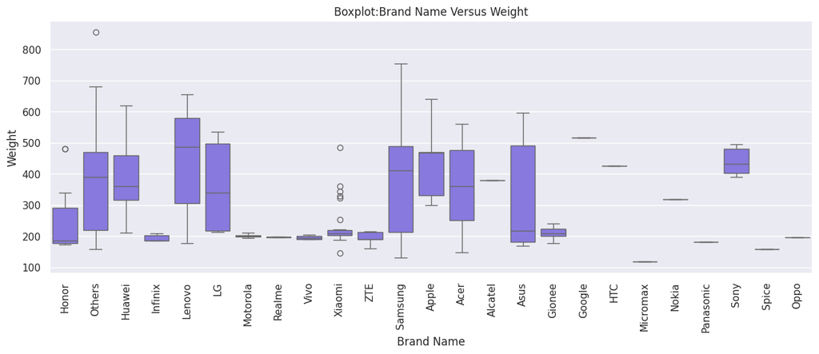

```python
plt.figure(figsize=(15, 5))
plt.title('Boxplot:Brand Name Versus Weight')
plt.ylabel('Weight')
plt.xlabel('Brand Name')
sns.boxplot(data = df_large_battery, x='brand_name', y='weight' ,color='mediumslateblue')
plt.xticks(rotation=90)
plt.show()
```

Observations:

```
*A lot of these have a large battery and and we see phones that are all easily recognizable, so despite these having large batteries people are still buying the phones/ tablets.
```

#### **Brands for Large Screens Analysis**

People who buy phones and tablets primarily for entertainment purposes prefer a large screen as they offer a better viewing experience. Let's create a new dataframe of only those devices which are suitable for such people and analyze.

```python
df_large_screen = df[df.screen_size > 6 * 2.54]
df_large_screen.shape
```

```
(1099, 15)
```

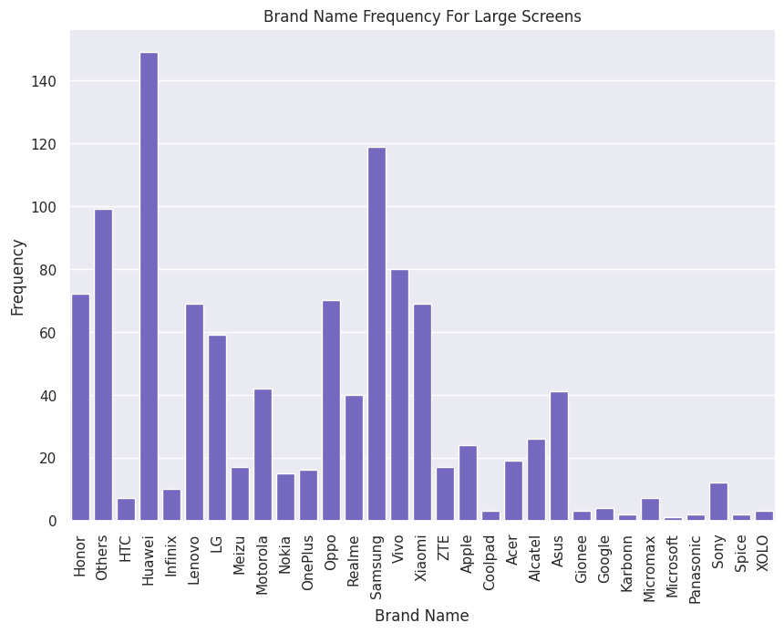

```python
plt.figure(figsize=(10,7))
plt.title("Brand Name Frequency For Large Screens")
plt.xlabel('Brand Name')
plt.ylabel('Frequency')

sns.countplot(data=df_large_screen, x='brand_name', color='slateblue')
plt.xticks(rotation=90)
plt.show()
```

#### **Selfie Camera versus Brand Analysis**

Everyone likes a good camera to capture their favorite moments with loved ones. Some customers specifically look for good front cameras to click cool selfies. Let's create a new dataframe of only those devices which are suitable for this customer segment and analyze.

```python
df_selfie_camera = df[df.selfie_camera_mp > 8]
df_selfie_camera.shape
```

```
(655, 15)
```

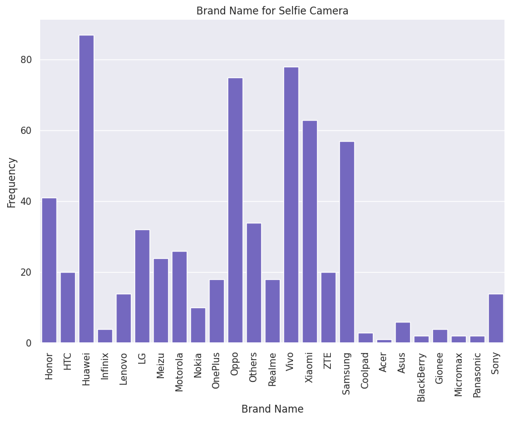

```python
plt.figure(figsize=(10,7))
plt.title("Brand Name for Selfie Camera")
plt.xlabel('Brand Name')
plt.ylabel('Frequency')

sns.countplot(data=df_selfie_camera, x='brand_name', color='slateblue')
plt.xticks(rotation=90)
plt.show()
```